# Analizing Forest Fire Data

### In this Notebook we are going to try to answer the following questions:

- During which months are forest fires most common?
- On which days of the week are forest fires most common?
- One showing the number of forest fires occuring during each month
- Another showing the number of forest fires occurring on each day of the week

```r
library(readr)
library(ggplot2)
library(dplyr)
library(purrr)
```

#### Reading the dataset:

```r
forest_fires <- read_csv("/home/matias/Documents/repos/Data-Science-Notebooks/Analyzing Forest Fire Data/forestfires.csv")
View(forest_fires)
forest_fires <- forest_fires %>%
  mutate(month = factor(month, levels = c("jan", "feb", "mar", "apr", "may", "jun", "jul", "aug", "sep", "oct", "nov", "dec")),
         day = factor(day, levels = c("sun","mon","tue","wed","thu","fri","sat")))
```

#### DISTRIBUTION OF NUMBER OF FIRES PER DAY AND PER MONTH:

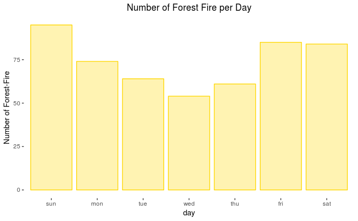

```r
fires_per_day <- forest_fires %>%
  group_by(day) %>%
  summarize(`Number of Forest-Fire` = n()) # %>%
fires_per_month <- forest_fires %>%
  group_by(month) %>%
  summarize(`Number of Forest-Fire` = n()) # %>%
ggplot(data = fires_per_day) +
  aes(x = day, y = `Number of Forest-Fire`) +
  geom_bar(stat = "identity", colour="gold", fill="gold", alpha=0.3) +
  theme(panel.background = element_rect(fill = "white"), plot.title = element_text(hjust = 0.5))    +
  labs(title = "Number of Forest Fire per Day")
```

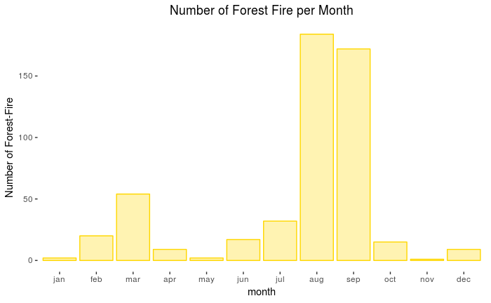

```r
ggplot(data = fires_per_month) +
  aes(x = month, y = `Number of Forest-Fire`) +
  geom_bar(stat = "identity", colour="gold", fill="gold", alpha=0.3) +
  theme(panel.background = element_rect(fill = "white"), plot.title = element_text(hjust = 0.5))    +
  labs(title = "Number of Forest Fire per Month")
```

#### DISTRIBUTION OF ANOTHER VARIABLES PER DAY AND PER MONTH.

FFMC: Fine Fuel Moisture Code index from the FWI system: 18.7 to 96.20 DMC: Duff Moisture Code index from the FWI system: 1.1 to 291.3 DC: Drought Code index from the FWI system: 7.9 to 860.6 ISI: Initial Spread Index from the FWI system: 0.0 to 56.10 temp: Temperature in Celsius degrees: 2.2 to 33.30 RH: Relative humidity in percentage: 15.0 to 100 wind: Wind speed in km/h: 0.40 to 9.40 rain: Outside rain in mm/m2 : 0.0 to 6.4 area: The burned area of the forest (in ha): 0.00 to 1090.84

```r
vars <- c("FFMC","DMC","DC","ISI","temp","RH","wind","rain")
create_box_plots_day <- function(x,y) {
  ggplot(data = forest_fires) +
    aes_string(x = x, y = y) +
    geom_boxplot(colour="darkorange", fill="papayawhip") +
    labs(title = "Variables per Day of the Week") +
    theme(panel.background = element_rect(fill = "white"), plot.title = element_text(hjust = 0.5))
}
create_box_plots_month <- function(x,y) {
  ggplot(data = forest_fires) +
    aes_string(x = x, y = y) +
    geom_boxplot(colour="firebrick2", fill="white") +
    labs(title = "Variables per Month") +
    theme(panel.background = element_rect(fill = "white"), plot.title = element_text(hjust = 0.5))
}
```

#### BOX PLOTS PER DAY

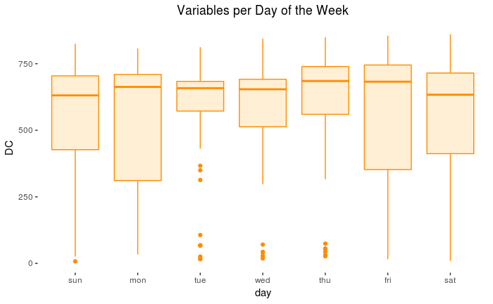

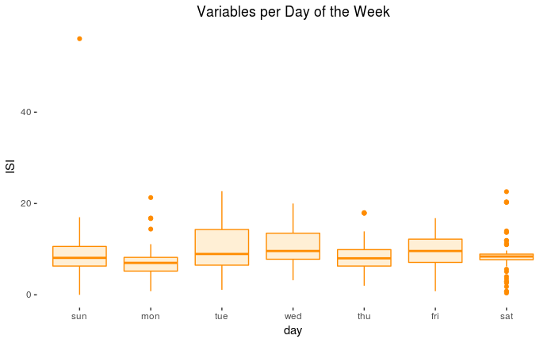

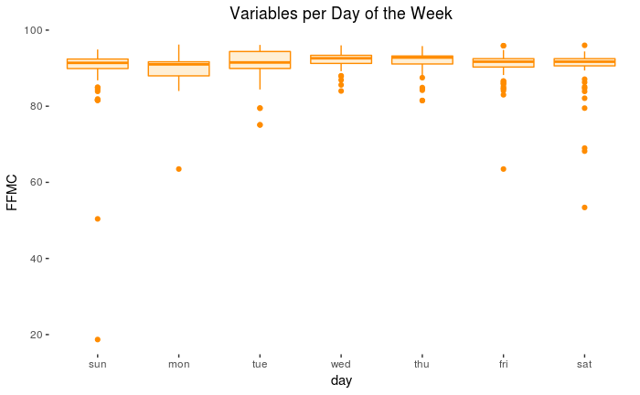

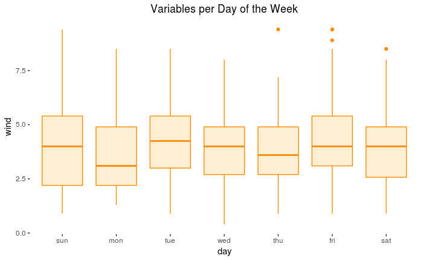

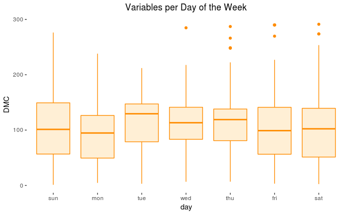

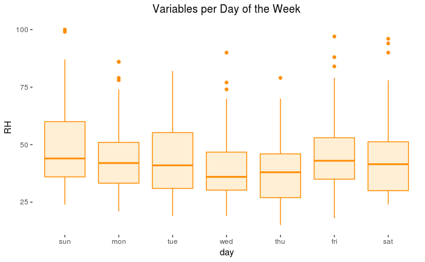

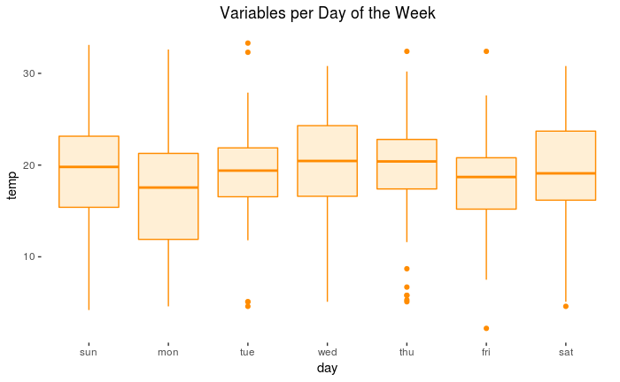

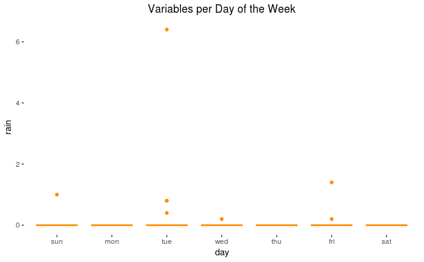

```r
x_var_day = names(forest_fires)[4]
y_var_day = names(forest_fires)[5:12]
map2(x_var_day, y_var_day, create_box_plots_day)
```

#### BOX PLOTS PER MONTH

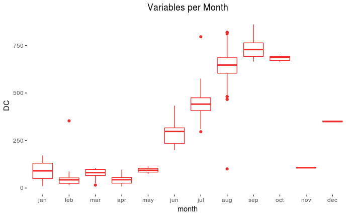

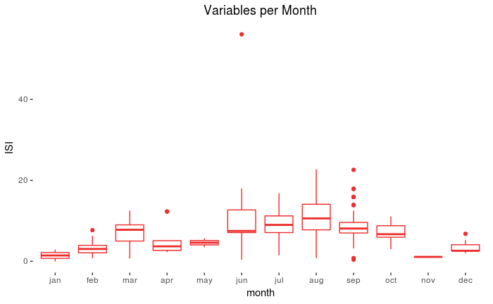

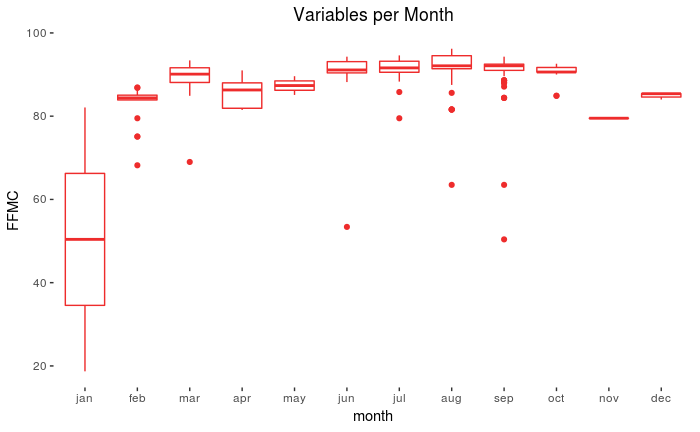

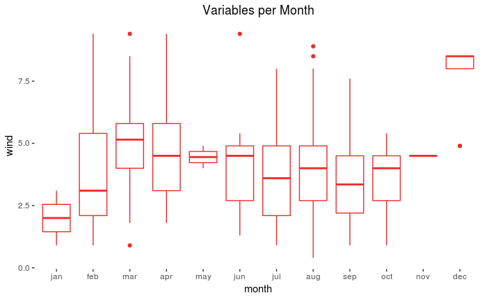

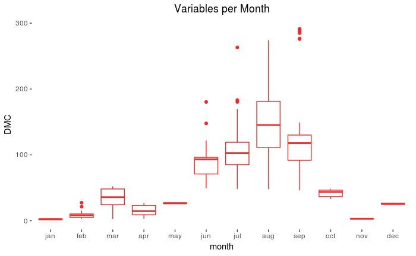

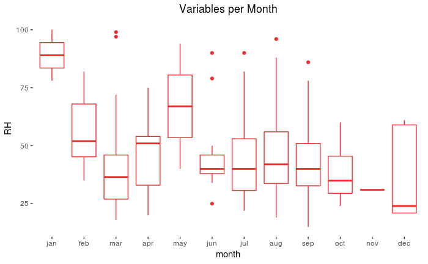

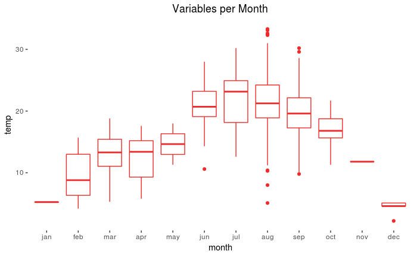

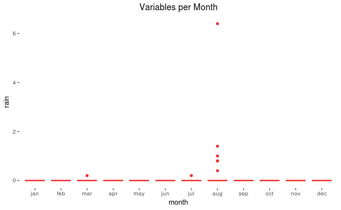

```r
x_var_month = names(forest_fires)[3]
y_var_month = names(forest_fires)[5:12]
map2(x_var_month, y_var_month, create_box_plots_month)
```

#### The area variable contains data on the number of hectares of forest that burned during the forest fire.

#### Perhaps we can use this variable as an indicator of the severity of the fire.

#### The idea is that worse fires will result in a larger burned area.

#### Let’s create scatter plots to see what can be learned about relationships between

#### The area burned by a forest fire and the following variables:

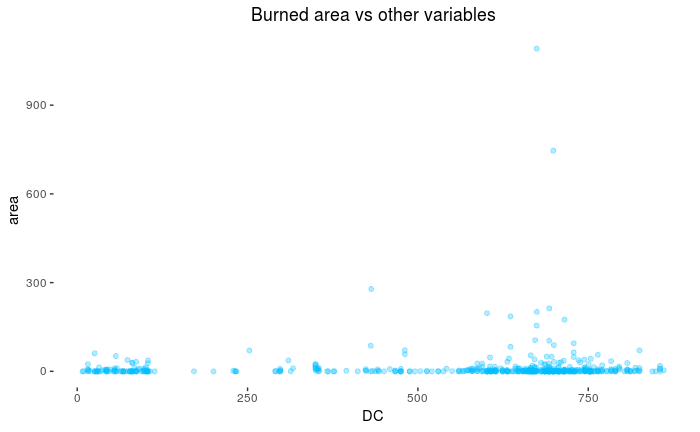

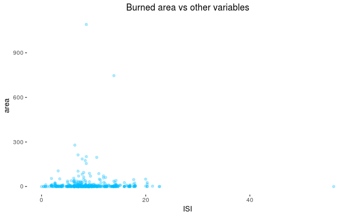

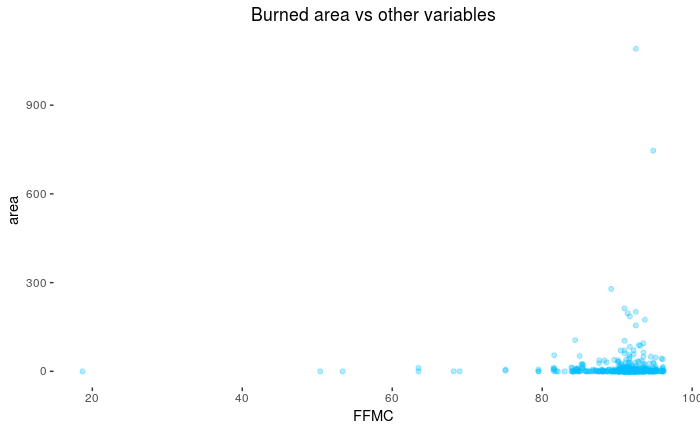

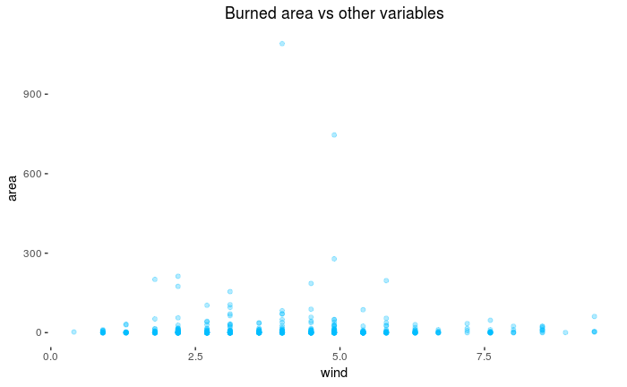

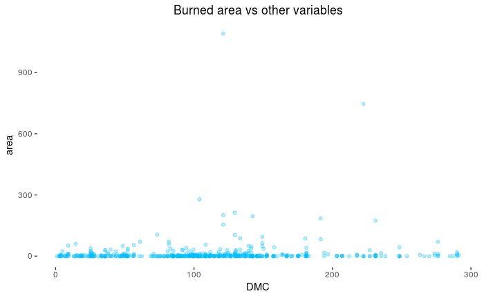

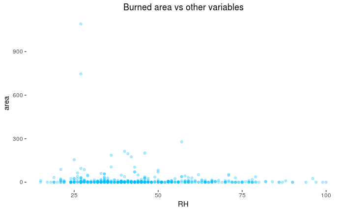

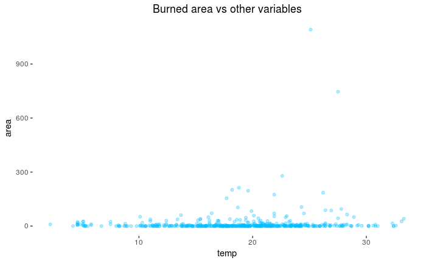

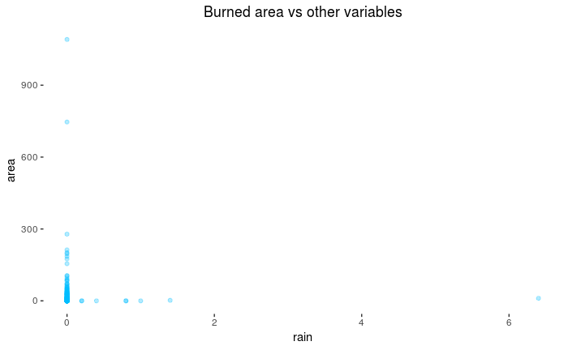

```r
create_scatter <- function(x,y) {
  ggplot(data = forest_fires) +
    aes_string(x = x, y = y) +
    geom_point(alpha = 0.3,  colour="deepskyblue") +
    labs(title = "Burned area vs other variables") +
    theme(panel.background = element_rect(fill = "white"), plot.title = element_text(hjust = 0.5))
}
x_var2 = names(forest_fires[5:12])
y_var2 = names(forest_fires[13])
map2(x_var2, y_var2, create_scatter)
```

#### The result is that most points are clustered around the bottom of the plots. A histogram of the area variable values clearly illustrates the distribution and why the scatter plots look the way they do:

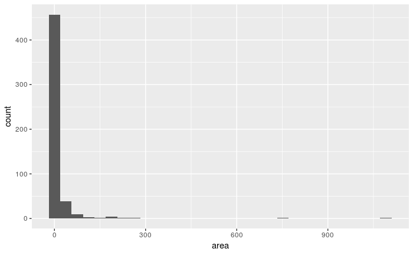

```r
ggplot(data = forest_fires) +
  aes(x = area) +
  geom_histogram()
```